# Exercises to Accompany TeachingWithR Workshop

2021 US Conference on Teaching Statistics

Matthew Beckman & Justin Post

June 25, 2021

# Part 1. RStudio IDE Scavenger Hunt

## 1.1 RStudio GUI

**Task:** Search the menus in your RStudio IDE to locate where each of the following can be accomplished:

1. Restart your R Session
2. Create a new “R Markdown” file
3. Install `lubridate` packages (with dependencies if needed)
4. search the Help to learn about the “head” function
5. What types of data sources can be imported using the RStudio GUI

### Solution

1. RStudio >> Session
2. RStudio >> File >> New File >> R Markdown
3. RStudio >> Packages >> Install >> [type the package name in the search bar]
4. RStudio >> Help >> [type “head” in search bar]
5. RStudio >> File >> Import Dataset

## 1.2 Configuration Details Handy for Teaching

**Task:** Visit “RStudio >> Tools >> Global Options” and locate the following:

1. Pane Layout
2. “Rainbow parenthesis”
3. “Show margin” (set to 80)
4. “Highlight selected line”
5. “Provide R style diagnostics (e.g., whitespace)”
6. “Show whitespace characters”

### Solution

1. Tools >> Global Options >> Pane Layout (in left-side navigation)
2. Tools >> Global Options >> Code >> Display
3. Tools >> Global Options >> Code >> Display
4. Tools >> Global Options >> Code >> Display
5. Tools >> Global Options >> Code >> Diagnostics
6. Tools >> Global Options >> Code >> Display

# Part 2. Import Data

## 2.1 Packages

- **Task 1:** call the `dcData` and `tidyverse` packages
  - Note: `dcData` is installed from GitHub, so it requires an extra step. You may have already done this from the instructions prior to the workshop, but it is shown again here if needed:
  - `devtools::install_github("mdbeckman/dcData")`
  - this might take a while (30+ sec?) depending on your Internet connection

### Solution

```r
## from instructions before workshop, if needed
# devtools::install_github("mdbeckman/dcData")

library(tidyverse)  # this actually loads a group of packages all at once
library(dcData)
```

## 2.2 Data Intake: `BabyNames`

- **Task 1:** Read `BabyNames` data from `dcData` into your R environment
  - Locate the `BabyNames` object in the Environment pane
  - Double click the object name to open a spreadsheet View
  - Spreadsheet view includes basic sorting capability
- **Task 2:** how many total rows of data are included?
- **Task 3:** describe what each row in the data *actually* represents.
- **Task 4:** find the largest `count` in the `BabyNames` data. How would you interpret this result?
- **Task 5:** what are the max & min available `year` in the data?

### Solution

Task 2.2.1:

```r
data("BabyNames", package = "dcData")
```

Task 2.2.2: about 1.8 million rows. We can see this from environment tab, spreadsheet view (footer), among other places

Task 2.2.3: The frequency of a given name, within a year, associated with a `sex`

Task 2.2.4: According to US Social Security records, 1947 was a banner year to name a female Linda!

Task 2.2.5: `BabyNames` data spans 1880 through 2013

## 2.3 Data Intake: `BabyNamesSupp`

The file “BabyNameSupp.csv” includes a few years of more recent data to augment the `BabyNames` data. Run the starter code shown below to read the data and complete the tasks.

**Important:** The starter code **will** produce a warning message! Don’t worry, it’s part of the exercise!

```r
# starter code for BabyNamesSupp
BabyNamesSupp <- read_csv("https://jbpost2.github.io/TeachingWithR/datasets/BabyNamesSupp.csv")
```

```
## Warning: 84619 parsing failures.
##   row col           expected actual                                                                 file
## 19208 sex 1/0/T/F/TRUE/FALSE      M 'https://jbpost2.github.io/TeachingWithR/datasets/BabyNamesSupp.csv'
## 19209 sex 1/0/T/F/TRUE/FALSE      M 'https://jbpost2.github.io/TeachingWithR/datasets/BabyNamesSupp.csv'
## 19210 sex 1/0/T/F/TRUE/FALSE      M 'https://jbpost2.github.io/TeachingWithR/datasets/BabyNamesSupp.csv'
## 19211 sex 1/0/T/F/TRUE/FALSE      M 'https://jbpost2.github.io/TeachingWithR/datasets/BabyNamesSupp.csv'
## 19212 sex 1/0/T/F/TRUE/FALSE      M 'https://jbpost2.github.io/TeachingWithR/datasets/BabyNamesSupp.csv'
## ..... ... .................. ...... ....................................................................
## See problems(...) for more details.
```

- **Task 1:** Read the warning message carefully; what seems to have gone wrong?
- **Task 2:** open the spreadsheet view to investigate `BabyNamesSupp`…
  - Which years of data are available to us in `BabyNamesSupp`?
  - Can you confirm what seems to have gone wrong during the data intake?
- **Task 3:** use the following R functions to investigate `BabyNamesSupp` further:
  - `head(BabyNamesSupp)`
  - `tail(BabyNamesSupp)`
  - `str(BabyNamesSupp)`
- **Task 4 (Challenge):** Why did `read_csv( )` seem to have this problem with the data intake? Any ideas how we might fix it?
  - Hint: “RStudio >> Help >> read_csv”
  - don’t worry about *actually* fixing it yet, just try to identify root cause.

At this point, we aren’t attempting to prepare the `BabyNamesSupp` data for analysis. We’re just reading it into the R environment and making observations. We’ll be using these data again in later exercises, so we will make the necessary corrections at that point.

### Solution

Task 2.3.1: The warning indicates a “parsing failure” and shows that R was expecting logical elements (e.g., TRUE/FALSE) and found “M” in many cases

Task 2.3.2: Yup, R interpreted “F” (meaning female in our data) to mean FALSE and then could not handle “M” appropriately as a result. These data include years 2014 through 2019.

Task 2.3.3:

```r
head(BabyNamesSupp)
```

| name | sex | count | year |
| --- | --- | --- | --- |
| Emma | FALSE | 20941 | 2014 |
| Olivia | FALSE | 19817 | 2014 |
| Sophia | FALSE | 18628 | 2014 |
| Isabella | FALSE | 17102 | 2014 |
| Ava | FALSE | 15708 | 2014 |
| Mia | FALSE | 13516 | 2014 |

```r
tail(BabyNamesSupp)
```

| name | sex | count | year |
| --- | --- | --- | --- |
| Zyhaire | NA | 5 | 2019 |
| Zyheem | NA | 5 | 2019 |
| Zykel | NA | 5 | 2019 |
| Zyking | NA | 5 | 2019 |
| Zyn | NA | 5 | 2019 |
| Zyran | NA | 5 | 2019 |

```r
str(BabyNamesSupp)
```

```
## tibble [196,177 × 4] (S3: spec_tbl_df/tbl_df/tbl/data.frame)
##  $ name : chr [1:196177] "Emma" "Olivia" "Sophia" "Isabella" ...
##  $ sex  : logi [1:196177] FALSE FALSE FALSE FALSE FALSE FALSE ...
##  $ count: num [1:196177] 20941 19817 18628 17102 15708 ...
##  $ year : num [1:196177] 2014 2014 2014 2014 2014 ...
##  - attr(*, "problems")= tibble [84,619 × 5] (S3: tbl_df/tbl/data.frame)
##   ..$ row     : int [1:84619] 19208 19209 19210 19211 19212 19213 19214 19215 19216 19217 ...
##   ..$ col     : chr [1:84619] "sex" "sex" "sex" "sex" ...
##   ..$ expected: chr [1:84619] "1/0/T/F/TRUE/FALSE" "1/0/T/F/TRUE/FALSE" "1/0/T/F/TRUE/FALSE" "1/0/T/F/TRUE/FALSE" ...
##   ..$ actual  : chr [1:84619] "M" "M" "M" "M" ...
##   ..$ file    : chr [1:84619] "'https://jbpost2.github.io/TeachingWithR/datasets/BabyNamesSupp.csv'" "'https://jbpost2.github.io/TeachingWithR/datasets/BabyNamesSupp.csv'" "'https://jbpost2.github.io/TeachingWithR/datasets/BabyNamesSupp.csv'" "'https://jbpost2.github.io/TeachingWithR/datasets/Bab…
##  - attr(*, "spec")=
##   .. cols(
##   ..   name = col_character(),
##   ..   sex = col_logical(),
##   ..   count = col_double(),
##   ..   year = col_double()
##   .. )
```

Task 2.3.4 (Challenge): The help documentation explains that `read_csv( )` guesses each variable type based on the first 1000 records. The data source had apparently sorted results such that the first 1000 (or more) rows were all “F” so `read_csv( )` concluded these to be logical (e.g., TRUE or FALSE) data. Quite a reasonable default under most circumstances, but shows why we should always carefully inspect our data intake!

## 2.4 Help Documentation for Data Sets

Search “RStudio >> Help” to learn about the data…

- **Task 1:** what can you learn about `BabyNames` data from RStudio Help?
- **Task 2:** what can you learn about `BabyNamesSupp` data from RStudio Help? What happened?

### Solution

Task 2.4.1: Lots! Sice this is loaded from an R package, the package author can make additional information available to you that describes the data, explains the variables, provides a source, etc.

Task 2.4.2: Nothing! The data were read from an external file, so R doesn’t have any information at all to share with us.

## 2.5 Data for 2020 (Challenge)

**Task 1:** Want to include 2020 data too? See if you can locate it, read the data into R, and review the data intake (hint: `BabyNames` help documentation includes a source to investigate).

Again, we aren’t attempting to process the 2020 data yet. We’re just reading it into the R environment and making observations about that process. We’ll be using this data again later in the exercises, so we will make the necessary corrections at that point.

## Solution

Task 2.5.1 (Challenge): visit “RStudio >> Help >> BabyNames >> Source” and then download the zip file to find the 2020 data inside. This can be read into R using `read_csv( )` even though the file extension is `.txt` since the data are comma delimited. You may note that the structure of the data differs slightly from our two other sources, so we will need some new tools to process it for use.

```r
## challenge
# locate zip file including all years of data, identify 2020 and read into R:
yob2020 <-
    read_csv("https://jbpost2.github.io/TeachingWithR/datasets/yob2020.txt",
             col_names = FALSE)
```

# Part 3. R Markdown

Note: you might hang onto the RStudio default text provided in the new R Markdown file for the moment… it’s packed with tiny examples that will come in handy!

## 3.1 Goal

We’ll be investigating the popularity of names in the US each year. Choose a few (4-5) names to investigate to you–friends, family, TV character, colleagues in the workshop!

### Solution (for example)

Matt has chosen the names of his family members: Matthew, Sarah, Eden, Jack, & Hazel.

## 3.2 Update yaml Header

- **Task 1:** “Knit” the document to render the initial HTML document
- **Task 2:** update yaml header as necessary to include an informative title, author name, & relevant date.
  - “Knit” to verify update
  - in general, Knit very often as you get the hang of the new tools

```
---
title: "Add a title"
author: "Add your name"
date: "Pick a date"
output: html_document
---
```

### Solution (for example)

Task 3.2.2: Your yaml header should appear at the beginning of the Rmd document, but here is some example text

```
---
title: "What's in a Name??"
author: "Matt Beckman & Justin Post"
date: "June 25, 2021"
output: html_document
---
```

## 3.3 Add Narrative & Code Chunk

- **Task 1:** Write a bit of narrative to introduce the project (no R code)
  - Which names have you chosen to investigate and why?
  - “Knit”
  - Add a bullet list of “famous” persons that share the name
  - “Knit”
  - Note: it really isn’t important *what* you write, we’re just practicing a few elements of R Markdown syntax.
- **Task 2:** create an R code chunk to set up for the investigation:
  - call the `tidyverse` and `dcData` packages
  - data intake:
    - `BabyNames` from `dcData` package
    - `BabyNamesSupp.csv` using `read_csv( )`
  - Although we had done much of this work previously, writing it into a code chunk within your R Markdown document more closely connects the analysis to your narrative, and takes a big step toward reproducibility.
- **Task 3:** Just for fun, add a note at the end of your document with a time/date stamp reflecting when the analysis was last modified. Call the R function `now()` directly from `lubridate` package INLINE for the time stamp.
  - For example, “These notes were last modified 2021-06-23 16:59:15”
  - “Knit” (notice the time stamp)
  - “Knit” again (notice the time stamp)

### Solution

Task 3.3.1:

Some sample narrative text follows; note that it is simply one long line of soft-wrapped text, and no formatting of any kind is imposed:

I’ve chosen to investigate the names of each person in my immediate family: Matthew, Sarah, Eden, Jack, and Hazel. They’re my favorite people, and also my favorite names! I’m a bit torn about how I’ll include my son Jack in the analysis. His legal name is “Jon” but he is nearly always called “Jack”–the spelling of “Jon” honors our scandinavian heritage on both sides of the family, and the nickname “Jack” specifically honors his great-grandfather.

Some famous persons by each name of the family include:

- Sarah Jessica Parker
- Eden Hazard
- Jack (Jackie) Robinson
- Hazel Findlay
- Richard Stallman. Seriously, the first hit of my Internet search for “famous Matthew” was Richard Stallman (!) whose given name is… Matthew. “Matthew the Apostle” (my namesake) was third on that particular list: https://playback.fm/people/first-name/matthew

Task 3.3.2

```r
# libraries
library(tidyverse)
library(dcData)

# data intake
data("BabyNames", package = "dcData")
BabyNamesSupp <- read_csv("https://jbpost2.github.io/TeachingWithR/datasets/BabyNamesSupp.csv",
                          col_types = cols(sex = col_character()))  # fixes `sex`
```

Task 3.3.3

```
This document was last modified 2021-06-23 16:59:16.
```

## 3.4 Render Various Output Formats

R Markdown is a flexible syntax that can render the same .Rmd (text) file in different formats. If you know the syntax, you can update the `output:` directly in the yaml header. RStudio provides a shortcut as a (tiny) menu arrow next to the “Knit (yarn)” icon revealing a few common choices.

- **Task 1:** MS Word
  - only if you have Microsoft Word installed on your computer already
  - use choice drop-down next to the “Knit (yarn)” shortcut
  - alternatively, update yaml with “`output: word_document`”
- **Task 2:** PDF
  - you may need this R command first: `tinytex::install_tinytex()`
  - use choice drop-down next to the “Knit (yarn)” shortcut
  - `output: pdf_document`
- **Task 3:** R Notebook
  - use choice drop-down next to the “Knit (yarn)” shortcut
  - `output: html_notebook`
  - note: the “Knit” button now says “Preview”–you will get the “Knit (yarn)” back when you revert to `output: html_document`
  - can you spot any differences b/w R Notebook & R Markdown doc?
- **Task 4 (challenge):** add some LaTeX to include mathematics your document (e.g, formula for the area of a circle) & “knit”

# Part 4. Data wrangling

## 4.1 Combine our Data Sets with `bind_rows( )`

- **Task 1:** use the starter code below to read the 2020 data:

```r
yob2020 <- read_csv("https://jbpost2.github.io/TeachingWithR/datasets/yob2020.txt",
                    col_names = FALSE, col_types = cols(X2 = col_character()))
```

- **Task 2:** the starter code from Task 4.1.1 includes a hint to correct the issue discovered when reading the `BabyNamesSupp` csv data file. Can you fix the issue with the `sex` column type?
- **Task 3:** before we combine our three data sources, let’s align them such that all three data sources are organized to include the same variables/columns, with the same names. Namely, the variables in the 2020 data should be renamed, and it needs a new variable to reflect the year (2020) for all rows. Note: the order of the columns are not important, as long as they have identical names in each data set to be combined.
- **Task 4:** use `bind_rows()` to combine `BabyNames` & `BabyNamesSupp` & the 2020 data

### Solution

```r
data("BabyNames", package = "dcData")

# Task 4.1.2
BabyNamesSupp <- read_csv("https://jbpost2.github.io/TeachingWithR/datasets/BabyNamesSupp.csv",
                          col_types = cols(sex = col_character()))  # fixes `sex`

# Tasks 4.1.1 & Task 4.1.3
BabyNames2020 <-
    read_csv("https://jbpost2.github.io/TeachingWithR/datasets/yob2020.txt",
             col_names = FALSE, col_types = cols(X2 = col_character())) %>%
    rename(name = X1, sex = X2, count = X3) %>%  # rename solution to Task 4.1.3
    mutate(year = 2020)                          # year solution to Task 4.1.3

# Task 4.1.4
BabyNamesFull <- bind_rows(BabyNames, BabyNamesSupp, BabyNames2020)
```

## 4.2 Data Wrangling and Summaries

- **Task 1:** filter the data to include only the names you wish to investigate
- **Task 2:** for each name, compute the total frequency across all years of available data (1880 through 2020) and then arrange the results in descending order by total.
- **Task 3:** for each combination of name AND sex, compute the total frequency across all years of available data (1880 through 2020) and then arrange the results by name.
- **Task 4:** filter the year you joined your current institution (or any specific, meaningful year you like) and repeat tasks 2 and 3.

```r
# vector of names
beckmans <- c("Matthew", "Sarah", "Eden", "Jack", "Hazel")

BabyNamesFull %>%
    filter(name %in% beckmans) %>%                   # Task 4.2.1
    group_by(name) %>%                               # Task 4.2.2
    summarise(total = sum(count, na.rm = TRUE)) %>%  # Task 4.2.2
    arrange(desc(total))
```

| name | total |
| --- | --- |
| Matthew | 1622951 |
| Sarah | 1086935 |
| Jack | 714762 |
| Hazel | 273991 |
| Eden | 45777 |

```r
BabyNamesFull %>%
    filter(name %in% beckmans) %>%
    group_by(name, sex) %>%                          # Task 4.2.3
    summarise(total = sum(count, na.rm = TRUE)) %>%  # Task 4.2.3
    arrange(name)
```

| name | sex | total |
| --- | --- | --- |
| Eden | F | 38138 |
| Eden | M | 7639 |
| Hazel | F | 271254 |
| Hazel | M | 2737 |
| Jack | F | 2682 |
| Jack | M | 712080 |
| Matthew | F | 5539 |
| Matthew | M | 1617412 |
| Sarah | F | 1083601 |
| Sarah | M | 3334 |

```r
# Task 4.2.4--Matt joined Penn State in 2015
BabyNamesFull %>%
    filter(name %in% beckmans, year == 2015) %>%
    group_by(name) %>%
    summarise(total = sum(count, na.rm = TRUE)) %>%
    arrange(desc(total))
```

| name | total |
| --- | --- |
| Matthew | 12775 |
| Jack | 8511 |
| Sarah | 4536 |
| Hazel | 4311 |
| Eden | 2638 |

```r
BabyNamesFull %>%
    filter(name %in% beckmans, year == 2015) %>%
    group_by(name, sex) %>%
    summarise(total = sum(count, na.rm = TRUE)) %>%
    arrange(name)
```

| name | sex | total |
| --- | --- | --- |
| Eden | F | 2065 |
| Eden | M | 573 |
| Hazel | F | 4299 |
| Hazel | M | 12 |
| Jack | F | 6 |
| Jack | M | 8505 |
| Matthew | F | 15 |
| Matthew | M | 12760 |
| Sarah | F | 4526 |
| Sarah | M | 10 |

# Part 5. Graph it

We want to create a graph that highlights the change in popularity among the names you have chosen over the years.

- **Task 1:** sketch (by hand) the plot you plan to make
  - note which variables are aligned to various aesthetics of your plot
  - does your plot include multiple layers?
- **Task 2:** is your data set aligned to the intended features of this plot?
  - do you need to summarise or mutate the data before creating the plot you have in mind?
  - do you need to filter the data to show a desired subset, or will all rows of the data be included?
  - when data are aligned to the needs of your plot, we sometimes call this a “glyph-ready” data set
- **Task 3:** run `esquisse::esquisser(GlyphReadyDataSet)` to draft a plot
  - `esquisser( )` allows you to prototype various plot features, and then view the corresponding `ggplot2` code for your plot
  - When you are satisfied, copy the R code and paste into Rmd code chunk
  - run the R code chunk to reproduce your plot in R Markdown
  - modifiy the plot code as needed to better align with the plot you intend (i.e., the one you sketched by hand).
  - ideally, you’ll soon skip the `esquisser( )` step as you get moer comfortable with the `ggplot2` framework
- **Task 4:** clean up axis labels, add a title, etc if you have not already done so.
- **Task 5** (Challenge): add a layer to somehow display overall birth trend for context
- **Task 6** (Challenge): plot the trend for each name as a relative frequency, rather than raw counts

### Solution

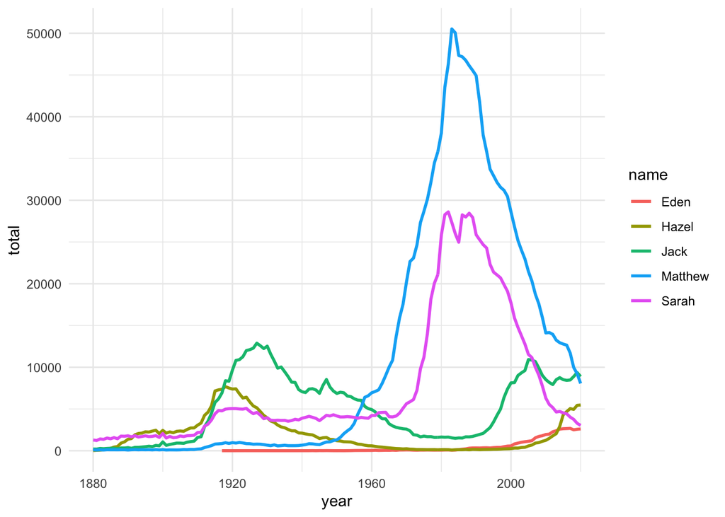

```r
library(esquisse)

# Task 5.1 My sketch was a line chart of name popularity over time
# variable mapping:
#    x-position: year
#    y-position: frequency
#    line color: name

# Task 5.2
BeckmanNamesLine <-
    BabyNamesFull %>%
    filter(name %in% beckmans) %>%
    group_by(name, year) %>%
    summarise(total = sum(count))
# Task 5.3
# esquisse::esquisser(BeckmanNamesLine)
ggplot(BeckmanNamesLine) +
 aes(x = year, y = total, colour = name) +
 geom_line(size = 1L) +
 scale_color_hue() +
 theme_minimal()
```

```r
# Task 5.4
TotalBabies <-
    BabyNamesFull %>%
    group_by(year) %>%
    summarise(totalBorn = sum(count, na.rm = TRUE))
```

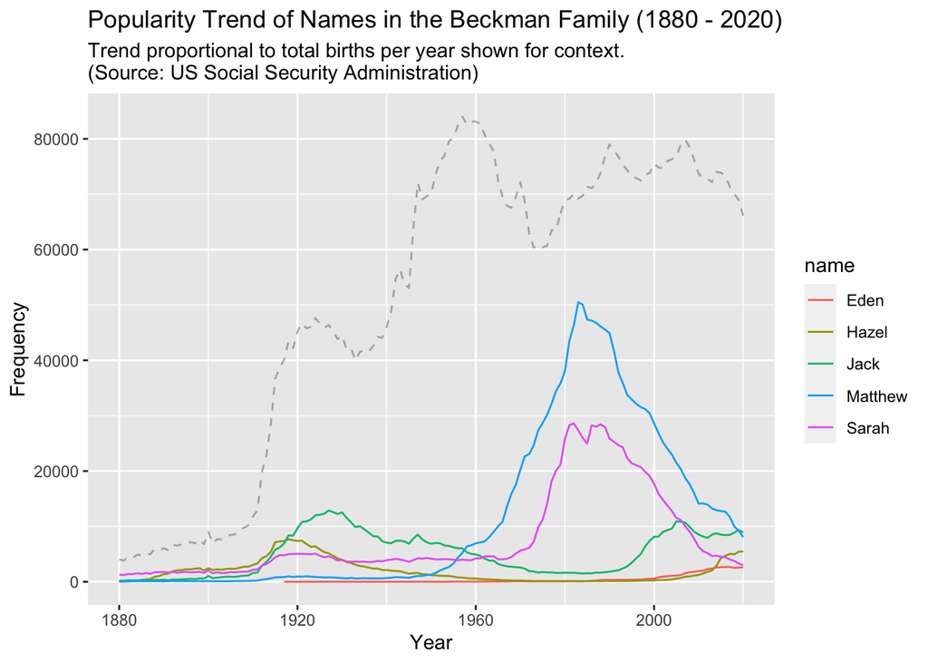

```r
# Task 5.5 (Challenge)
# add context propotional to total births each year to the plot
ggplot(BeckmanNamesLine) +
    geom_line(aes(x = year, y = total, colour = name)) +
    geom_line(data = TotalBabies, aes(x = year, y = totalBorn * 0.02),
              linetype = "dashed", alpha = 0.3, ) +
    ggtitle(label = "Popularity Trend of Names in the Beckman Family (1880 - 2020)",
            subtitle = "Trend proportional to total births per year shown for context.\n(Source: US Social Security Administration)") +
    ylab("Frequency") +
    xlab("Year")
```

```r
# Task 5.6 (Challenge)
BeckmanNamesRF <-
    BabyNamesFull %>%
    group_by(year) %>%                    # groups for subsequent mutate()
    mutate(annualTotal = sum(count)) %>%  # new column for yearly totals
    ungroup() %>%
    filter(name %in% beckmans) %>%
    group_by(name, year) %>%              # new groups for subsequent summarise()
    summarise(prop = sum(count) / annualTotal)
```

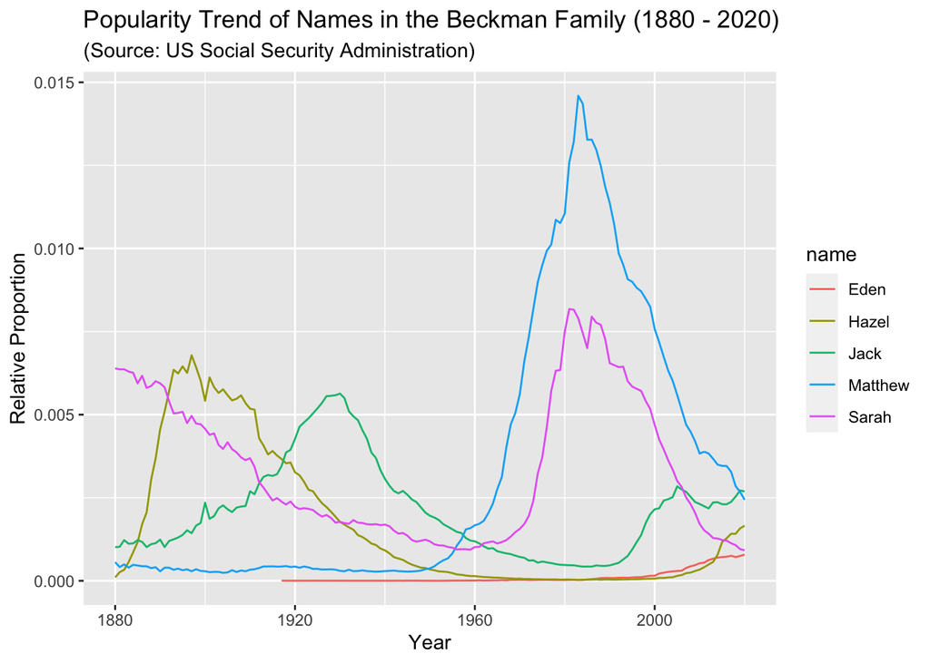

```r
ggplot(BeckmanNamesRF) +
    geom_line(aes(x = year, y = prop, colour = name)) +
    ggtitle(label = "Popularity Trend of Names in the Beckman Family (1880 - 2020)",
            subtitle = "(Source: US Social Security Administration)") +
    ylab("Relative Proportion") +
    xlab("Year")
```